# M362M: Introduction to Stochastic Processes - Fall 2024 Syllabus

### COURSE-SPECIFIC INFORMATION

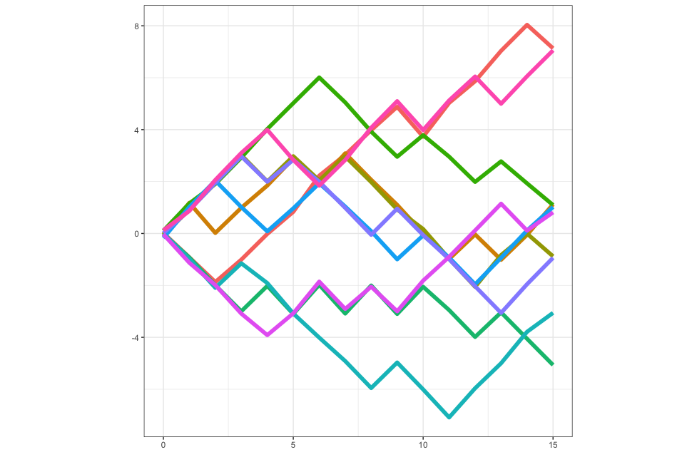

Welcome to M362M. Here is some information and some ground rules. Read carefully and let me know if there is anything unclear. This syllabus is only subject to minimal change when needed due to unforseen circumstances, changes will be posted on **Canvas**.

### Basic info

**Course number.** M362M (54060)

**Course meets.** Room: PMA 5.120, Times: TuTh 3:30pm - 5:00pm

**Flags.** QR (quantitative reasoning)

**Instructor.** Matias G. Delgadino

**Email.** Use Canvas to email

**Office Hours.** *Instructor*: Office Math 10.160 Tu 5pm and Wed 3pm (Do feel free to remind me, that you are coming...). For a *private* meeting to discuss class performance, email me directly.

*Grader:* TBA.

### Course info

**Course Description.** M362M is an undergraduate course on stochastic processes and applications. We focus on several classes of elementary stochastic processes which are often used in various applications such as random walks, discrete Markov chains and, time permitting, the Poisson process and Brownian motion. The course will promote the generative approach to probability and the use of computer simulations.

**Learning Objectives.**

- Students will get acquainted with mathematical tools and techniques, as well as the probabilistic intuition necessary for understanding and successful use of stochastic models in a variety of applications within mathematics and in science, engineering, economics, etc. They will also learn how to build new models, in yet-unencountered situations and novel frameworks.
- Students will become familiar with the basics of the programming language R and the RStudio IDE. They will learn how to use R to simulate random variables and stochastic processes. Those skills will allow them to answer a much wider spectrum of questions about the behavior of stochastic processes, compared to a purely analytic approach.

**Prerequisites.** The formal prerequisits are the grade B or better in M362K and a grade of at least C- in 340L or 341 with a grade of at least C-.

Students are assumed to be at home with the basics of probability as presented in, e.g., Ross’s [First Course in Probability](https://www.pearson.com/us/higher-education/program/Ross-First-Course-in-Probability-A-10th-Edition/PGM1786065.html), Pitman’s [Probability](https://www.springer.com/us/book/9780387979748) or Asimow and Maxwell’s [Probability and Statistics with Applications](https://books.google.com/books/about/Probability_and_Statistics_with_Applicat.html?id=ZL3QQZsp6DAC); there will be a brief review. Also, a good working knowledge of calculus - especially sequences and series - is assumed; no review will be given.

Students are not assumed to have any prior programming experience and the basics of R will be covered from scratch.

**Textbook.** There is no required textbook. Lecture notes written by the instructor will be posted online at https://gordanz.github.io/M362M. The students in need of an additional source of problems (or explanation) are referred to the following books:

1. [Essentials of Stochastic Processes](https://link.springer.com/book/10.1007/978-1-4614-3615-7) by Rick Durrett (a free version is available at http://www.math.duke.edu/~rtd/EOSP/EOSP2E.pdf),
2. [Adventures in Stochastic Processes](https://link.springer.com/book/10.1007/978-1-4612-0387-2) by Sidney I. Resnick,
3. [Introduction to Probability Models](https://www.sciencedirect.com/book/9780128143469/introduction-to-probability-models) by Sheldon Ross.

**Online resources.**

1. The course-management system **Canvas** will be used in this course to keep track of grades, serve as a repository of links to other resources and to relay various announcements. The students are responsible for the contents of these announcements. The easiest way not to miss any is to turn on (i.e. not turn off) *Announcements* in their account’s *Notification* menu.
2. **Lecture Capture** will be used automatically for classes, and will be directly available on **Canvas**.
3. This term we will be using **Discord** for class discussion (Invite: https://discord.gg/hdBdeKXw3J). The system is highly catered to getting you help fast and efficiently from classmates and myself. Rather than emailing questions to the instructor, I encourage you to post your questions on there. I will moderate discussions, and any abuse or harassment will not be tolerated.
4. A set of **online lecture notes** written by the instructor will be provided to students; you can access them at https://gordanz.github.io/M362M These notes will include numbered problems, some of which will be featured in hw assignments. All course materials will be available on **Github** in the public repository https://github.com/gordanz/M362M. If you don’t know what Github is, or if you simply do not want to use it, don’t worry; everything will be linked to from Canvas.

### Assessment and grading

**Homework assignments.** A weekly or bi-weekly homework will be assigned (with the assignments posted on Canvas). The submission will be **electronic**, through Canvas. Detailed instructions on the proper format of your submissions will be posted in due time (we need to cover a little bit of R before that). Submit well before the deadline - the system has been known to get “overwhelmed” close to it. If everything else fails, send your file(s) directly to the instructor (before the deadline!) with a detailed explanation of the difficulties you experienced. Late hw will not be accepted.

You are allowed (and, in fact, encouraged) to work on your homework in groups of up to 4 people, and to submit a single document per group. Do not forget to include the names of all group members. Two lowest hw scores will be dropped.

If you miss an exam *for a documented reason* (illness, approved and previously announced religious holiday, or some other extraordinary circumstance), make-up arrangements will be made on a case-by-case basis.

**Final grade.** The final grade is composed as follows:

| Assignment | Percentage of final grade |
| --- | --- |
| Homework | 40% |
| Exams | 60% (20% each) |

The class will be completely *curved*. More specifically, your relative rank in the class will determine your final grade, absolute grade values will not matter in deciding grades. I will regularly post where *cutoff* grades lie, except in exceptional circumstances the distribution will be approximately 1/3 **A**, 1/3 **B** , and 1/3 **C**.

### GENERAL, UNIVERSITY- or STATE-MANDATED INFORMATION

**Drop dates.** The procedure/consequences are different, depending on whether you drop before or after the 12th day of classes (09/11), and then, before or after the *main drop (Q-drop) date* (11/20). (See https://ugs.utexas.edu/vick/academic/adddrop for details)

**Students with Disabilities.** The University of Texas at Austin provides upon request appropriate academic accommodations for qualified students with disabilities. If you have a documented disability and you need specific support as a result of your disability, please let me know as soon as possible, but definitely within the first 3 weeks of class. For more information, contact the Office of the Dean of Students at 471-6259, 471-4641 (TTY), 1-866-329- 3986 (video phone) or go to http://ddce.utexas.edu/disability/

**Counseling and mental health.** Counseling and other mental-health services are available from **Counseling and Mental Health Center**, Student Services Bldg (SSB), 5th Floor. (hours: M–F 8am–5pm. phone: 512 471 3515, web: http://www.cmhc.utexas.edu)

**Religious holy days.** Religious holy days sometimes conflict with class and examination schedules. Sections 51.911 and 51.925 of the Texas Education Code relate to absences by students and instructors for observance of religious holy days.

Section 51.911 states that a student who misses an examination, work assignment, or other project due to the observance of a religious holy day must be given an opportunity to complete the work missed within a reasonable time after the absence, provided that they have properly notified each instructor.

It is the policy of The University of Texas at Austin that the student must notify each instructor at least fourteen days prior to the classes scheduled on dates he or she will be absent to observe a religious holy day. For religious holidays that fall within the first two weeks of the semester, the notice should be given on the first day of the semester. The student may not be penalized for these excused absences but the instructor may appropriately respond if the student fails to complete satisfactorily the missed assignment or examination within a reasonable time after the excused absence.

**Title IX Reporting/SB 212.** Texas *Senate Bill 212* requires all employees of Texas universities, including faculty, report any information to the [Title IX Office](https://titleix.utexas.edu/) regarding sexual harassment, sexual assault, dating violence and stalking that is disclosed to them. Your instructor in a **mandatory reporter**. By law, your instructor must be fired if she does not report. Our [Student Ombuds](https://ombuds.utexas.edu/student) is confidential. Additionally, if you wish to speak with someone who can provide support **without** making an official report to the university, contact a confidential advocate at the [Office of the Dean of Students](https://deanofstudents.utexas.edu/emergency/confidentialadvocates.php) by emailing advocate@austin.utexas.edu.

If you would like to speak with a case manager, who can provide support, resources, or academic accommodations, in the Title IX Office, please email supportandresources@austin.utexas.edu. Case managers can also provide support, resources, and accommodations for pregnant, nursing, and parenting students.

For more information about reporting options and resources, please visit: https://titleix.utexas.edu, contact the Title IX Office via email at titleix@austin.utexas.edu, or call 512-471-0419.

**Sanger Learning Center.** All students are welcome to take advantage of Sanger Center’s classes and workshops, private learning specialist appointments, peer academic coaching, and tutoring for more than 70 courses in 15 different subject areas. For more information, please visit http://www.utexas.edu/ugs/slc or call 512-471-3614 (JES A332).

**Important Safety Information.** If you have concerns about the safety or behavior of fellow students, TAs or Professors, call BCAL (the Behavior Concerns Advice Line): 512-232-5050. Your call can be anonymous.

Further information about (campus) safety and security can be obtained from the Office of Campus Safety and Security, 512-471-5767, http://www.utexas.edu/safety/

Occupants of buildings on The University of Texas at Austin campus are required to evacuate buildings when a fire alarm is activated. Alarm activation or announcement requires exiting and assembling outside.

- Familiarize yourself with all exit doors of each classroom and building you may occupy. Remember that the nearest exit door may not be the one you used when entering the building.
- Students requiring assistance in evacuation shall inform their instructor in writing during the first week of class.
- In the event of an evacuation, follow the instruction of faculty or class instructors. Do not re-enter a building unless given instructions by the following: Austin Fire Department, The University of Texas at Austin Police Department, or Fire Prevention Services office.
- Link to information regarding emergency evacuation routes and emergency procedures can be found at: http://www.utexas.edu/emergency

**Academic (dis)Honesty.** Students who violate University rules on academic dishonesty are subject to disciplinary penalties, including the possibility of failure in the course and/or dismissal from the University. Since such dishonesty harms the individual, all students, and the integrity of the University, policies on academic dishonesty will be strictly enforced. For further information, please visit the Student Conduct and Academic Integrity website at: http://deanofstudents.utexas.edu/conduct For a more detailed document, please consult: https://catalog.utexas.edu/general-information/appendices/appendix-c/student-conduct-and-academic-integrity/ Please, pay particular attention to the section on *plagiarism.*

### The SCHEDULE of CLASSES

[output not shown]